# Assignment 1

Linzi Yu

# An Introduction to the exposome: environment-wide association in body mass index and fasting glucose

Please check Canvas for the due date of this assignment.

**Start early.** This is a challenging assignment! Each student must hand in their code and answers separately. This assignment is 25% of your grade. We cannot accept late assignments.

Submit your answers as a knitted .html file: select the Knit drop down at the top of the window. Once converted to .html, select the file in the file browser, click the More drop down, and select Export.

```r
library(tidyverse)
```

## Background:

Body mass index and glucose are phenotypic traits that are known to be risk factors for Type 2 Diabetes (T2D). Genetic factors are associated with body mass index and glucose. However, environmental exposure factors associated to fasting glucose and/or body mass index may also play a role in T2D, given the rapid rise of both body mass index and diabetes in the last 20 years (https://www.cdc.gov/diabetes/statistics/slides/long_term_trends.pdf).

For example, it is hypothesized that poor diets or sugar consumption may influence body mass index or fasting glucose. However, these factors do not predict the phenotypes of body mass index or fasting glucose completely. In this assignment you will complement these associations in T2D, linking new potential environmental exposures in T2D clinical phenotypes. Specifically, we will execute a data-driven search for environmental exposures correlated with body mass index and fasting glucose, called ‘environment-wide association studies’ or ‘exposome-wide association studies’ (EWASs), similar to how investigators correlate individual SNPs with disease in GWAS.

### Description of Data and Readings:

Please skim [Patel et al 2010](https://www.ncbi.nlm.nih.gov/pmc/articles/PMC2873978/).

```r
load('./assignment1_2022.Rdata')
```

This .Rdata file contains 5 data.frames and an array named the following:

- ExposureDescription:the dictionary of exposure variables in the training and testing datasets
- ExposureList: a list of biomarkers of environmental exposures to test against BMI and glucose.
- NHData.train: the training dataset from the NHANES 1999-2000 and 2001-2002 surveys
- NHData.test: the testing dataset from the NHANES 2003-2004 and 2005-2006 surveys
- demographicVariables: a dictionary of demographic variables in the training and testing datasets.

These data were derived from the National Health and Nutrition Examination Survey (NHANES), a survey on a representative sample of the United States population, undertaken by the US Centers for Disease Control and Prevention (see here: https://www.cdc.gov/nchs/nhanes/. Specifically, we downloaded the data from the NHANES web site and stitched them together to create the data.frame objects above. For more information, please see our paper, [Patel CJ, et al 2016, Nature Scientific Data](http://www.nature.com/articles/sdata201696).

# A short tutorial on analysis of survey data

The NHANES participants are representative of the United States population. A challenge in making a dataset representative is ensuring all types of individuals are sampled that reflect the diversity of the US at the lowest possible cost. Simply calling a finite number of people up randomly is not going to achieve representativeness. The US CDC and National Centers for Health Statistics (NCHS) are able to achieve representativeness by sampling specific facets of the population at higher probabilities than would be observed if one was to randomly sample the population. Second, NCHS samples people from specific parts of the population (e.g., 15 counties a year) to save time and money (it is easier to survey people in a neighborhood than randomly all over the US).

In fact, most data that you will find from the US CDC or international epidemiological surveys, use a special sampling technique called “survey sampling”. You can learn more about the CDC and the NCHS sampling procedure here: https://wwwn.cdc.gov/Nchs/Nhanes/AnalyticGuidelines.aspx

What does this mean for us? We cannot use the common tools in R to do modeling if we desire to produce “valid” effect sizes, associations/correlations, and pvalues. Why? Because individuals are not sampled randomly, they exhibit some inherent correlation with others (e.g., individuals sampled from the same town, for example). Therefore, this will influence the standard errors and averages of the correlations and therefore also influence the inference (pvalues for correlation).

How do we address this? We simply use a package, aptly called ‘survey’, to take into account the unequal survey-weighted design of the NHANES population. The two main functions you will use in this assignment to achieve this includes ‘svydesign’ and ‘svyglm’ (survey-weighted general linear modeling, which can do linear, logistic, and other types of regressions). Here is how you use them using the NHdata.train data.frame.

First, we need to load the ‘survey’ package:

```r
library(survey)
```

Next, we need to tell R that we have a survey-weighted data we need to analyze. This is done through the ‘svydesign’ function from the survey library, for example for the training data, NHData.train:

```r
dsn <- svydesign(ids=~SDMVPSU, strata=~SDMVSTRA, weights=~WTMEC2YR, nest=T, data=NHData.train)
```

This tells R that we have a survey-weighted sample (denoted by weights in the function above). The weights signify how much an individual should be considered in the model and is a function of their prevalence in the population. For example, individuals with higher weights are less prevalent in the population. In contrast, in a simple random sample, the weights would be equal for every individual. Second, the ids and strata parameters tell R where an individual was sampled. ‘Strata’ are units (such as zipcodes) that are sampled within ‘primary sampling units’ (or PSUs, SDMVPSU) such as a county. Individuals within strata are more correlated with one another than individuals that live in different strata. Therefore, these similarities within sampling strata must be taken into account when estimating correlations.

We can run regression models using the ‘svyglm’ function. For example, suppose I wanted to regress Body Mass Index (coded as BMXBMI in the data.frame) on age (coded as RIDAGEYR), we can use the ‘svyglm’ function (INSTEAD of the regular ol’ ‘lm’ function):

```r
mod <-svyglm(BMXBMI ~ RIDAGEYR, dsn)
summary(mod)
```

```
##
## Call:
## svyglm(formula = BMXBMI ~ RIDAGEYR, design = dsn)
##
## Survey design:
## svydesign(ids = ~SDMVPSU, strata = ~SDMVSTRA, weights = ~WTMEC2YR,
##     nest = T, data = NHData.train)
##
## Coefficients:
##              Estimate Std. Error t value Pr(>|t|)
## (Intercept) 20.662323   0.144659  142.84   <2e-16 ***
## RIDAGEYR     0.145503   0.003441   42.29   <2e-16 ***
## ---
## Signif. codes:  0 '***' 0.001 '**' 0.01 '*' 0.05 '.' 0.1 ' ' 1
##
## (Dispersion parameter for gaussian family taken to be 45.1212)
##
## Number of Fisher Scoring iterations: 2
```

Observe that the estimates (and pvalues) will be different when using the ‘lm’ function (give it a shot):

```r
mod2 <- lm(BMXBMI ~ RIDAGEYR, data=NHData.train)
summary(mod2)
```

```
##
## Call:
## lm(formula = BMXBMI ~ RIDAGEYR, data = NHData.train)
##
## Residuals:
##     Min      1Q  Median      3Q     Max
## -18.868  -4.396  -1.225   3.070  40.347
##
## Coefficients:
##              Estimate Std. Error t value Pr(>|t|)
## (Intercept) 20.428038   0.077834  262.46   <2e-16 ***
## RIDAGEYR     0.141623   0.002013   70.37   <2e-16 ***
## ---
## Signif. codes:  0 '***' 0.001 '**' 0.01 '*' 0.05 '.' 0.1 ' ' 1
##
## Residual standard error: 6.21 on 17470 degrees of freedom
##   (3532 observations deleted due to missingness)
## Multiple R-squared:  0.2208, Adjusted R-squared:  0.2208
## F-statistic:  4951 on 1 and 17470 DF,  p-value: < 2.2e-16
```

In this assignment, we will use the survey package and ‘svydesign’ and ‘svyglm’ functions to run your association tests. These are good functions to know when analyzing data from the public domain.

Answer the questions that are numbered in the space below that says “your answer here”. Supply R code when required by using the back ticks. For example:

## Sample Questions (and Answers):

1. What is the meaning of life?

The meaning of life is 42.

2. What is e to the power of 3?

```r
exp(3)
```

```
## [1] 20.08554
```

# A. Background Questions

1. How are the phenotypes (glucose and BMI) measured in participants of the NHANES? (1)
- Answer: According to Nhanes cookbook https://wwwn.cdc.gov/Nchs/Nhanes/2001-2002/L10AM_B.htm, The enzyme hexokinase (HK) catalyzes the reaction between glucose and adenosine triphosphate (ATP) to form glucose-6-phosphate (G-6-P) and adenosine diphosphate (ADP). In the presence of nicotinamide adenine dinucleotide (NAD), G-6-P is oxidized by the enzyme glucose-6-phosphate dehydrogenase (G-6-PD) to 6-phosphogluconate and reduced nicotinamide adenine dinucleotide (NADH). The increase in NADH concentration is directly proportional to the glucose concentration and can be measured spectrophotometrically at 340 nm.

BMXBMI is the Body Mass Index (kg/m**2). According to Nhanes cookbook https://wwwn.cdc.gov/Nchs/Nhanes/2001-2002/BMX_B.htm, “All body measures were obtained by trained health technicians. The body measurement component was performed in a specially equipped room in the mobile examination center (MEC). The health technician was assisted by a trained recorder. The technician and recorders worked as a team to position, measure, and record the body measurement data accurately.”

2. What does representative mean with respect to NHANES? Why is it a different than say, the Framingham Heart Study? (2)
- Answer: Representatives of NHANES are selected to reflect the diversity of the US instead of sampling the people randomly. Acording to CDC, NHANES tended to achieve representativeness by sampling specific facets of the population at higher probabilities than would be observed if one was to randomly sample the population.
3. These phenotypes (glucose and BMI) are related to type 2 diabetes. (a) Draw the E, G, P, and D diagram and annotate what you are investigating in your anticipated NHANES EWASs. (b) What does body mass index measure? What does fasting glucose measures? Why are they important in type 2 diabetes? (2)
- your answers here (in free text, some hints below)

E (Diet/sugar etc.)  
↘  
P (BMI&Glucose) → D (T2D)  
↗  
G

a: - Phenotype(s): body mass index and glucose - Exposure(s): Blood cadmium, Blood lead etc. 160 exposures - Disease(s): T2D

b: According to CDC (https://www.cdc.gov/healthyweight/assessing/bmi/adult_bmi/index.html), Body mass index (BMI) is a person’s weight in kilograms divided by the square of height in meters. Fasting glucose measures the blood sugar after an overnight fast (not eating).

BMI appears to be as strongly correlated with various metabolic and disease outcome as are these more direct measures of body fatness. BMI is an inexpensive and easy screening method for weight category—underweight, healthy weight, overweight, and obesity. A blood sugar level of 200 mg/dL or higher indicates you have diabetes.

4. How are the environmental exposures measured in the NHANES? Choose a few examples (up to 5) of different types of biomarkers of environmental exposures from the ExposureList array and query the NHANES website for the assay description of the biomarker. (2)
- Answer: Environmental exposures are indicated by series of biomarkers in the Exposure list. Each biomarker is directly or indirectly related to some environmental exposure. LBXBCD - Blood cadmium (ug/L) LBXBPB - Blood lead (ug/dL) LBXTHG - Mercury, total (ug/L)

### Let’s explore the phenotypes, body mass index (BMXBMI) and fasting glucose (LBXGLU) with respect to demographic characteristics of your population in the training dataset (NHData.train)

5. How many individuals are there with BMI values? Draw a histogram of BMI and describe the mean and median. Is the distribution “skewed” or biased toward a certain direction on the x axis? (1)

```r
#Individuals BMI value not NA
NHData.train %>% filter(!is.na(BMXBMI)) %>% count()
```

```
##       n
## 1 17472
```

17472 individuals have validated BMI values.

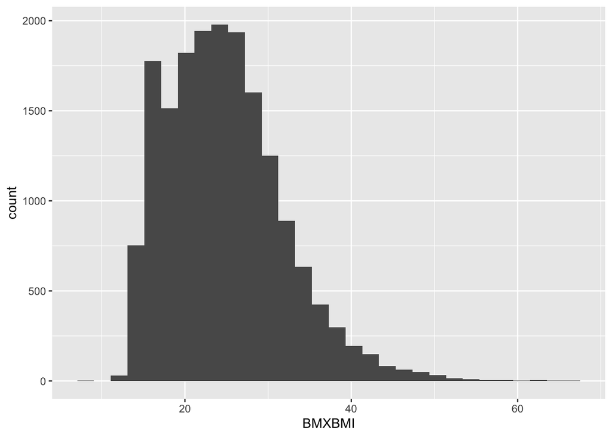

```r
#BMI histogram
ggplot(NHData.train, aes(BMXBMI))+
  geom_histogram()
```

```r
#mean and median
mean(NHData.train$BMXBMI, na.rm = TRUE)
```

```
## [1] 24.79468
```

```r
median(NHData.train$BMXBMI, na.rm = TRUE)
```

```
## [1] 24.1
```

The distribution has a positive skew.

6. Plot BMI vs age. (1)

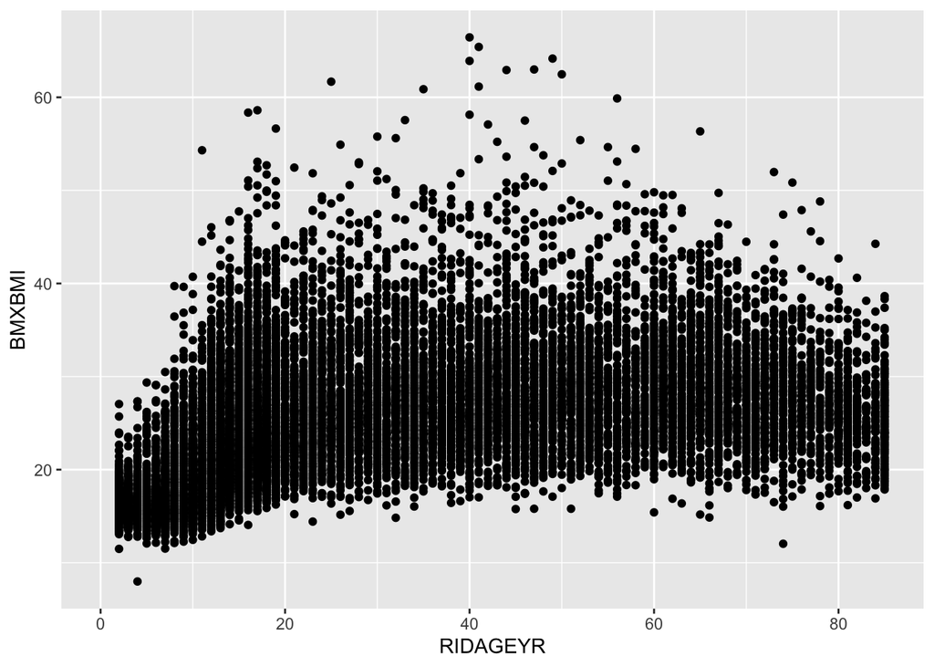

```r
#scatterplot
ggplot(NHData.train, aes(RIDAGEYR,BMXBMI))+
  geom_point()
```

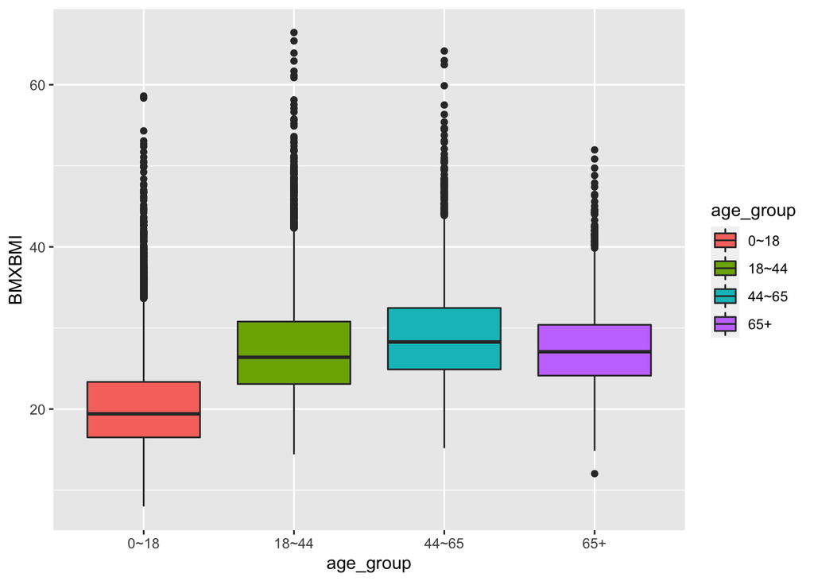

```r
#boxplot after grouping
NHData.train <- NHData.train %>% mutate(age_group = case_when(age_0_18 == '1' ~ '0~18',
                                                              age_18_44 == '1' ~ '18~44',
                                                              age_44_65 == '1' ~ '44~65',
                                                              age_65_plus == '1' ~ '65+'))
ggplot(NHData.train, aes(age_group,BMXBMI,fill=age_group))+
  geom_boxplot()
```

7. Plot a boxplot of BMI versus sex. (1)
- your answer here

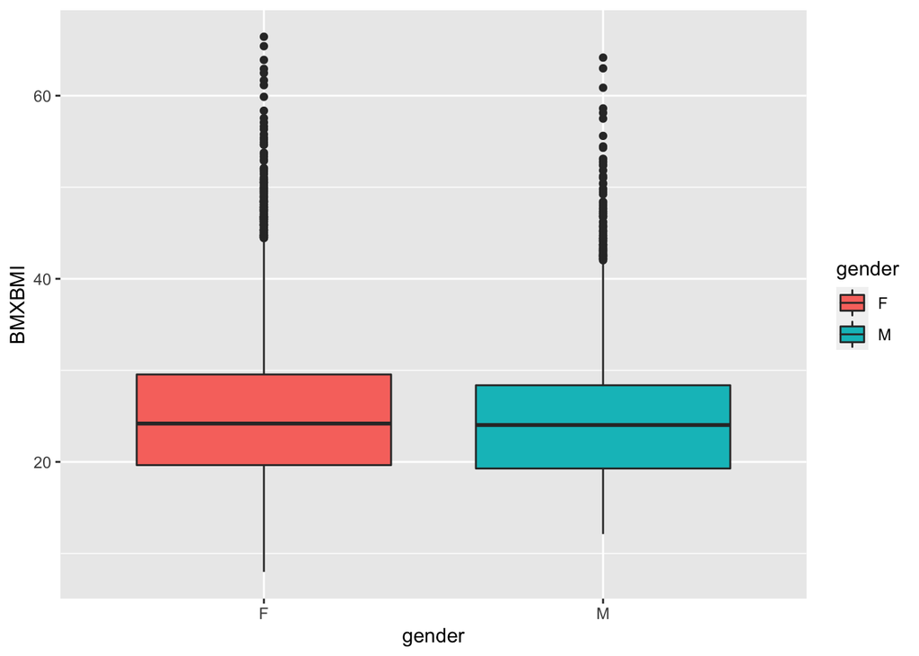

```r
NHData.train <- NHData.train %>% mutate(gender = case_when(female == '1' ~ 'F',
                                           male == '1' ~ 'M' ))
ggplot(NHData.train, aes(gender,BMXBMI,fill=gender))+
  geom_boxplot()
```

8. Plot a boxplot of BMI versus race/ethnicity. (2)
- your answer here

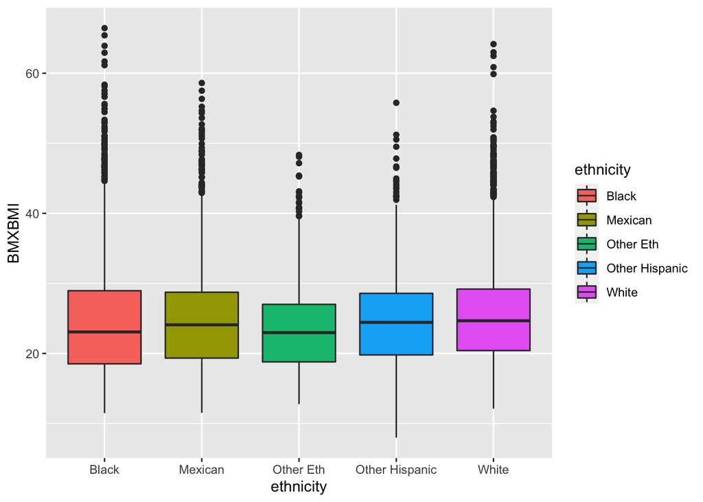

```r
NHData.train <- NHData.train %>% mutate(ethnicity = case_when(white ==  '1' ~ 'White',
                                                                black == '1' ~ 'Black',
                                                           mexican == '1' ~ 'Mexican',
                                                           other_hispanic == '1' ~ 'Other Hispanic',
                                                           other_eth == '1' ~ 'Other Eth'))
NHData.train %>% filter(!is.na(ethnicity)) %>%
  ggplot( aes(ethnicity,BMXBMI,fill=ethnicity))+
  geom_boxplot()
```

9. Plot BMI versus an indicator of socioecononomic status, the income to poverty ratio (INDFMPIR). The income-to-poverty ratio is a the household income divided by the household poverty level for a given survey year. Therefore a Income-to-poverty ratio of 1 means the individual has household income equal to the poverty level. (1)
- your answer here

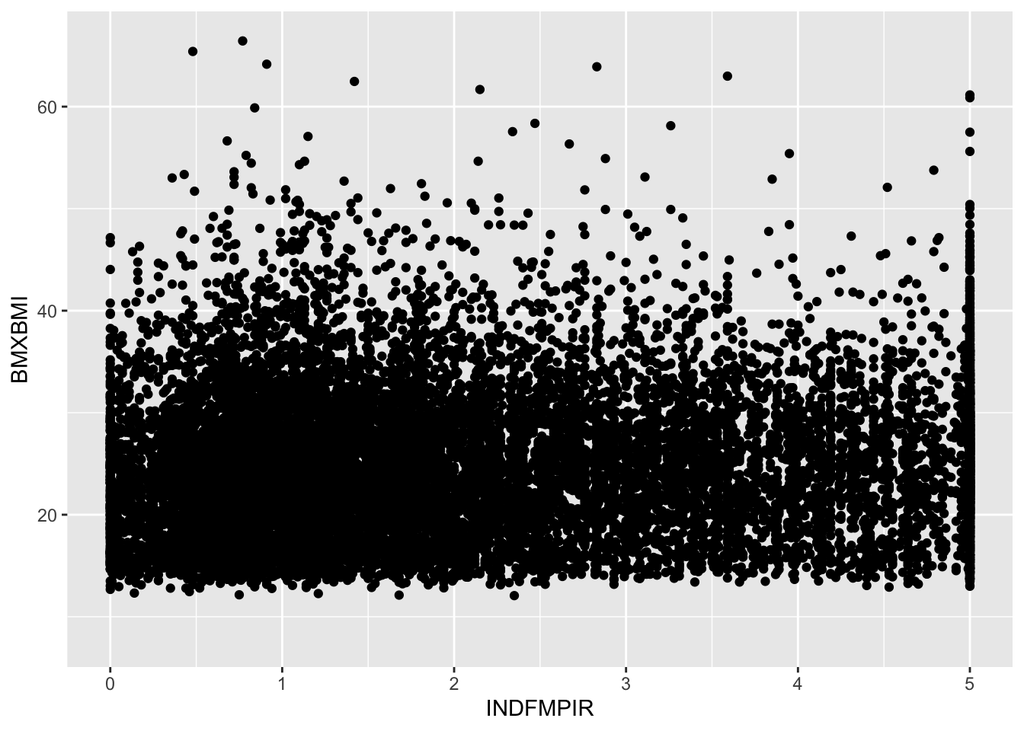

```r
# start from simple scatter plot
ggplot(NHData.train, aes(INDFMPIR,BMXBMI))+
  geom_point()
```

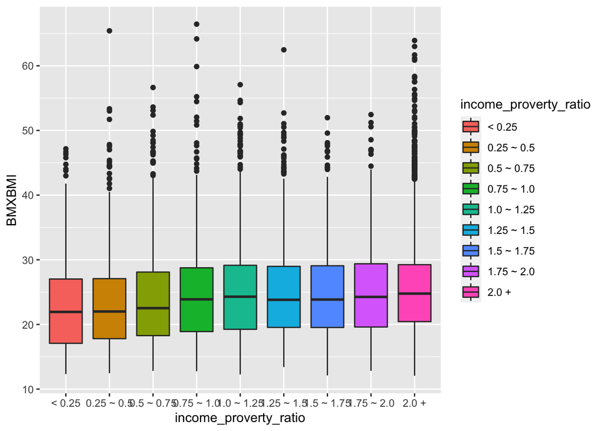

```r
# group the income proverty ratio level and make a bloxplot
NHData.train <- NHData.train %>% mutate(income_proverty_ratio = case_when(INDFMPIR <.25 ~ '< 0.25',
                                                           .25 < INDFMPIR & INDFMPIR < 0.5  ~ '0.25 ~ 0.5',
                                                            0.5 < INDFMPIR & INDFMPIR < 0.75 ~ '0.5 ~ 0.75',
                                                            .75 < INDFMPIR & INDFMPIR < 1.0  ~ '0.75 ~ 1.0',
                                                           1.0  < INDFMPIR & INDFMPIR < 1.25 ~ '1.0 ~ 1.25',
                                                           1.25 < INDFMPIR & INDFMPIR < 1.5  ~ '1.25 ~ 1.5',
                                                            1.5 < INDFMPIR & INDFMPIR < 1.75 ~ '1.5 ~ 1.75',
                                                            1.75 < INDFMPIR & INDFMPIR < 2.0  ~ '1.75 ~ 2.0',
                                                           2 < INDFMPIR ~ '2.0 +'))
NHData.train %>% filter(!is.na(income_proverty_ratio)) %>%
  ggplot(aes(income_proverty_ratio,BMXBMI,fill=income_proverty_ratio))+
  geom_boxplot()
```

10. Describe the differences in groups (e.g., what is the difference of BMI averages in males vs. females): summarizing the plots from 6-9. (1)
11. What statistical model would you use to test the association (and significance) of your findings in 10? Execute the model using svyglm below, using *multivariate regression*, modeling BMI as a function of age, ethnicity, sex, and INDFMPIR. (3)

Linear Regression Model under Survey setting.

```r
# Change the reference category of ethnicity to be White.
table(NHData.train$ethnicity)
```

```
##
##          Black        Mexican      Other Eth Other Hispanic          White
##           4909           6169            847           1106           7973
```

```r
NHData.train$ethnicity <- relevel(factor(NHData.train$ethnicity), ref = "White")
# Run the lm model
dsn <- svydesign(ids=~SDMVPSU, strata=~SDMVSTRA, weights=~WTMEC2YR, nest=T, data=NHData.train)
mod <-svyglm(BMXBMI ~ RIDAGEYR + ethnicity + gender + INDFMPIR, dsn)
summary(mod)
```

```
##
## Call:
## svyglm(formula = BMXBMI ~ RIDAGEYR + ethnicity + gender + INDFMPIR,
##     design = dsn)
##
## Survey design:
## svydesign(ids = ~SDMVPSU, strata = ~SDMVSTRA, weights = ~WTMEC2YR,
##     nest = T, data = NHData.train)
##
## Coefficients:
##                          Estimate Std. Error t value Pr(>|t|)
## (Intercept)             20.426108   0.257944  79.188  < 2e-16 ***
## RIDAGEYR                 0.152421   0.003439  44.325  < 2e-16 ***
## ethnicityBlack           1.560491   0.180950   8.624 1.66e-08 ***
## ethnicityMexican         0.992781   0.190223   5.219 3.10e-05 ***
## ethnicityOther Eth      -0.012941   0.612393  -0.021    0.983
## ethnicityOther Hispanic  0.553229   0.281339   1.966    0.062 .
## genderM                 -0.209020   0.132947  -1.572    0.130
## INDFMPIR                -0.061980   0.056904  -1.089    0.288
## ---
## Signif. codes:  0 '***' 0.001 '**' 0.01 '*' 0.05 '.' 0.1 ' ' 1
##
## (Dispersion parameter for gaussian family taken to be 44.90787)
##
## Number of Fisher Scoring iterations: 2
```

### Using the model you described in 11, report the following:

12. Change in BMI for a 1 year increase/change in age and significance of this association. (1) MBI increase 0.152421. P value < 2e-16, significant.
13. Difference of BMI in males versus females and significance. (1) A male is lower in BMI by 0.209020 compared to a female. P value = 0.130 > 0.05, not significant.
14. Difference of BMI in Non-Hispanic Black versus Whites, Mexican American versus Whites, and Other Hispanic vs. White, and Other versus White. (1) Non-Hispanic Blacks increase BMI by 1.560491 compared to Whites, P value = 1.66e-08 < 0.05, significant. Mexican American increase BMI by 0.992781 compared to Whites, P value = 3.10e-05 < 0.05, significant. Other Hispanic increase BMI by 0.553229 compared to Whites, P value = 0.062 > 0.05, not significant. Other ethnicities lower BMI by 0.012941 compared to Whites, P value = 0.983 > 0.5, not at all significant.
15. Repeat Q11 for fasting glucose (LBXGLU), developing a multivariate linear regression model to associate fasting glucose with age, sex, race, and income-poverty ratio. (3)

```r
# Run the lm model
dsn <- svydesign(ids=~SDMVPSU, strata=~SDMVSTRA, weights=~WTMEC2YR, nest=T, data=NHData.train)
mod2 <-svyglm(LBXGLU ~ RIDAGEYR + gender + ethnicity + INDFMPIR, dsn)
summary(mod2)
```

```
##
## Call:
## svyglm(formula = LBXGLU ~ RIDAGEYR + gender + ethnicity + INDFMPIR,
##     design = dsn)
##
## Survey design:
## svydesign(ids = ~SDMVPSU, strata = ~SDMVSTRA, weights = ~WTMEC2YR,
##     nest = T, data = NHData.train)
##
## Coefficients:
##                         Estimate Std. Error t value Pr(>|t|)
## (Intercept)              82.3329     1.0918  75.412  < 2e-16 ***
## RIDAGEYR                  0.4186     0.0291  14.388 1.13e-12 ***
## genderM                   5.5616     0.8217   6.768 8.41e-07 ***
## ethnicityBlack            0.1312     1.4520   0.090  0.92884
## ethnicityMexican          3.4764     0.9499   3.660  0.00138 **
## ethnicityOther Eth        3.0543     3.2390   0.943  0.35594
## ethnicityOther Hispanic   3.9009     2.8895   1.350  0.19073
## INDFMPIR                 -0.9295     0.2844  -3.268  0.00352 **
## ---
## Signif. codes:  0 '***' 0.001 '**' 0.01 '*' 0.05 '.' 0.1 ' ' 1
##
## (Dispersion parameter for gaussian family taken to be 1024.717)
##
## Number of Fisher Scoring iterations: 2
```

### We will explore one biomarker of exposure: serum Lead (LBXBPB).

16. Plot a histogram of serum lead (LBXBPB) and qualitatively describe the “shape” of the distribution - what does it look like? Is centered or skewed in a direction? (1)

The distribution has a positive skew.

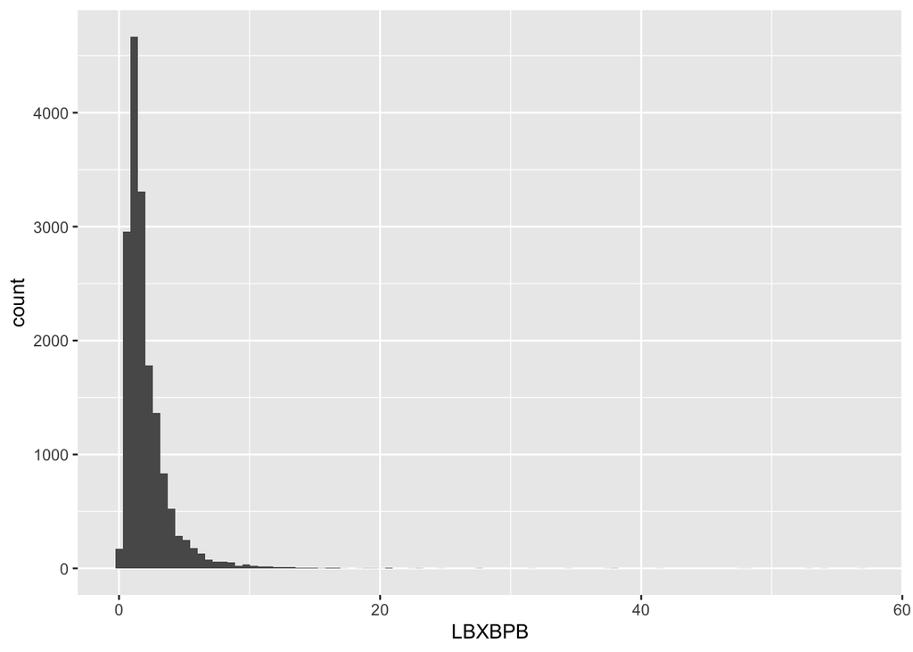

```r
#serum lead (LBXBPB) histogram
ggplot(NHData.train, aes(LBXBPB))+
  geom_histogram(bins = 100)
```

Investigators attempt to make this distribution more “normal” or symmetrically centered around a value by applying a “transformation” to make the linear associations easier to interpret. Since the lead levels seem to have an exponential-like decay a log-based transformation is used. Lets take a look at the log base e of lead levels:

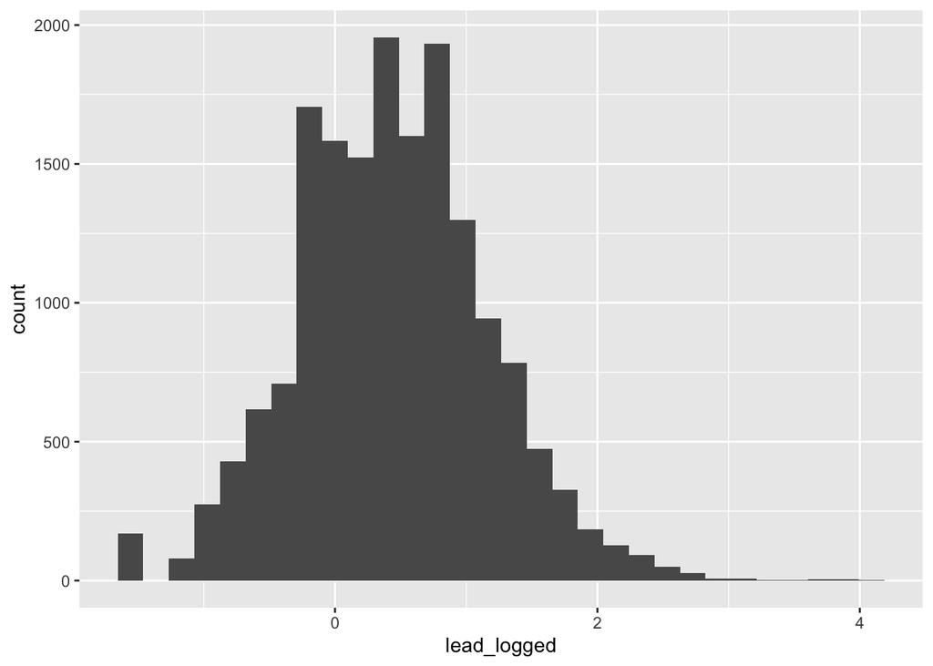

```r
NHData.train <- NHData.train %>% mutate(lead_logged = log(LBXBPB+ .001)) # add 0.001 for values that are 0
p <- ggplot(NHData.train, aes(lead_logged))
p <- p + geom_histogram()
p
```

### Using a multivariate linear regression model, estimate the following:

17. Execute a multivariate linear regression model to associate log (blood lead levels [plus .001, a small constant]) with age, sex, race, and income-poverty ratio, again in the training cohort (NHData.train) (3)

```r
# Run the lm model
dsn <- svydesign(ids=~SDMVPSU, strata=~SDMVSTRA, weights=~WTMEC2YR, nest=T, data=NHData.train)
mod3 <- svyglm(lead_logged ~ RIDAGEYR + gender + ethnicity + INDFMPIR, dsn)
summary(mod3)
```

```
##
## Call:
## svyglm(formula = lead_logged ~ RIDAGEYR + gender + ethnicity +
##     INDFMPIR, design = dsn)
##
## Survey design:
## svydesign(ids = ~SDMVPSU, strata = ~SDMVSTRA, weights = ~WTMEC2YR,
##     nest = T, data = NHData.train)
##
## Coefficients:
##                           Estimate Std. Error t value Pr(>|t|)
## (Intercept)             -0.0296231  0.0328105  -0.903  0.37638
## RIDAGEYR                 0.0109253  0.0005453  20.035 1.28e-15 ***
## genderM                  0.4316016  0.0127236  33.921  < 2e-16 ***
## ethnicityBlack           0.1718230  0.0224377   7.658 1.21e-07 ***
## ethnicityMexican         0.1010466  0.0355791   2.840  0.00953 **
## ethnicityOther Eth      -0.0401062  0.0386275  -1.038  0.31042
## ethnicityOther Hispanic  0.0003425  0.0475020   0.007  0.99431
## INDFMPIR                -0.0648098  0.0054698 -11.849 5.07e-11 ***
## ---
## Signif. codes:  0 '***' 0.001 '**' 0.01 '*' 0.05 '.' 0.1 ' ' 1
##
## (Dispersion parameter for gaussian family taken to be 0.4047992)
##
## Number of Fisher Scoring iterations: 2
```

## B. Executing environment-wide associations

### Logging and scaling exposure variables

#### Logging variables

As above, to handle the right skew of exposure biomarkers, the measurements are log transformed. We add a constant (0.001). If we have a model such as the following:

```r
mod <- svyglm(LBXGLU ~ log(LBXBPB + .001), dsn)
summary(mod)
```

```
##
## Call:
## svyglm(formula = LBXGLU ~ log(LBXBPB + 0.001), design = dsn)
##
## Survey design:
## svydesign(ids = ~SDMVPSU, strata = ~SDMVSTRA, weights = ~WTMEC2YR,
##     nest = T, data = NHData.train)
##
## Coefficients:
##                     Estimate Std. Error t value Pr(>|t|)
## (Intercept)          98.2936     0.6279 156.535  < 2e-16 ***
## log(LBXBPB + 0.001)   4.3218     0.6638   6.511 4.68e-07 ***
## ---
## Signif. codes:  0 '***' 0.001 '**' 0.01 '*' 0.05 '.' 0.1 ' ' 1
##
## (Dispersion parameter for gaussian family taken to be 1107.804)
##
## Number of Fisher Scoring iterations: 2
```

How would you interpret the coefficient? Answer: for a 1 unit change in the log10(exposure), you have a 10 unit increase (9.95) in fasting glucose mg/dL.

Another way to interpret this is in terms of (percentages)[https://stats.oarc.ucla.edu/sas/faq/how-can-i-interpret-log-transformed-variables-in-terms-of-percent-change-in-linear-regression/]: a 1% change in the lead levels is associated with a 0.04 mg/dL (=4.32/100) higher serum glucose level. However this is association is not independent of potential confounding variables.

#### Scaling variables

Different variables have different units (e.g., mg/dL for lead levels). When we execute EWAS, we wish for every association to be comparable, or on the same units. Therefore, we need to “scale” the exposure variables to be on the same unit for each variable. One intuitive way to scale is to make all variables on the unit of standard deviation of that variable (e.g., sd(exposure)), dividing each measurement for each individual by the standard deviation of the population after subtracting the mean (centering the distribution at “0”). In code, to standardize or scale lead levels (after logging):

```r
NHData.train <- NHData.train %>% mutate(lead_standardized = scale(log(LBXBPB+.001))) # Ways to standardize or "scale" LBXBPB

NHData.train %>% summarize(m1= mean(lead_standardized, na.rm=T), m2 = mean(log(LBXBPB + .001), na.rm=T), s1 = sd(lead_standardized, na.rm = T), s2=sd(log(LBXBPB + .001), na.rm=T)) ## m1 should be 0, s1 should be equal to 1
```

```
##             m1        m2 s1        s2
## 1 2.872113e-17 0.4598617  1 0.7132666
```

### Doing EWAS

Now we will test each of the exposures in ExposureList for linear association with a quantitative or continuous trait in the training and testing datasets separately.

The script should input a the training or testing datasets and output a tibble that contains the exposure ID (e.g., LBXBPB),exposure name, phenotype name,estimate,standard error, pvalue, an false discovery rate (FDR).

Your code should execute associations that associate between each exposure in ExposureList and the phenotype (e.g., BMI). The association should quantify how much the phenotype changes for a 1 standard deviation change in the logarithm base 10 of the exposure value (e.g., scale(log(exposure + 0.001))).

Because some of the exposure variables contain 0 values we need to add a constant before doing a log transformation. Choosing a constant is a matter of hot debate. For the sake of the exercise, use a small constant equal to 0.001. The dependent variable is the phenotype, and the independent variable is an exposure. Include age, sex, race/ethnicity, and income/poverty ratio (INDFMPIR) as covariates.

Execute the following:

1. EWAS on 1 standard deviation change of Body Mass Index (BMXBMI) in the training and testing datasets separately. Use ‘svyglm’ as the regression approach of choice (see function below). (5)

```r
# here is an (optional) function you can use to take in phenotype and exposure variables as "string" input to a linear regression:

### function to do a pairwise association between a phenotype and exposure
association <- function(phenotype="BMXBMI", exposure="LBXBCD", covariates=c("male", "RIDAGEYR"), dsn) {
  # phenotype: a string that is a phenotype name (e.g., "BMXBMI")
  # exposure: a string this is a exposure name (e.g., "LBXBCD")
  # covariates: an array of covariate variables
  # dsn: the survey design object
  covariate_string <- paste(covariates, collapse="+")
  mod_string <- sprintf('scale(%s) ~ scale(log(%s + .001)) + %s', phenotype, exposure, covariate_string)
  # the above formats formula as a string
  mod <- svyglm(as.formula(mod_string), dsn)
  return(mod)
}

# run an association between BMI and Blood cadmium, adjusting for male sex and age in years
assoc_test_model <- association("BMXBMI", "LBXBCD", dsn=dsn)
summary(assoc_test_model)
```

```
##
## Call:
## svyglm(formula = as.formula(mod_string), design = dsn)
##
## Survey design:
## svydesign(ids = ~SDMVPSU, strata = ~SDMVSTRA, weights = ~WTMEC2YR,
##     nest = T, data = NHData.train)
##
## Coefficients:
##                              Estimate Std. Error t value Pr(>|t|)
## (Intercept)                -0.5107741  0.0285754 -17.875 3.99e-16 ***
## scale(log(LBXBCD + 0.001)) -0.0134758  0.0104972  -1.284   0.2106
## male                       -0.0469241  0.0196257  -2.391   0.0243 *
## RIDAGEYR                    0.0196819  0.0005952  33.070  < 2e-16 ***
## ---
## Signif. codes:  0 '***' 0.001 '**' 0.01 '*' 0.05 '.' 0.1 ' ' 1
##
## (Dispersion parameter for gaussian family taken to be 0.9237198)
##
## Number of Fisher Scoring iterations: 2
```

```r
# your code here:
# run the association function for each exposure in Exposure List
library(broom)
## training dataset
dsn <- svydesign(ids=~SDMVPSU, strata=~SDMVSTRA, weights=~WTMEC2YR, nest=T, data=NHData.train)
i = 1
# Run all the Exposure models and CREATE a output tibble
BMI_training_models <- tibble(ExposureList) %>%
  add_column(expo_name = "", phenotype = 'BMXBMI', estimate = 0, standard_err = 0, p = 0, FDR = 0)
for (ele in ExposureList) {
  BMI_training_model <- association("BMXBMI", ele ,covariates=c("RIDAGEYR", "male", "ethnicity", "INDFMPIR"), dsn=dsn)
  BMI_training_models[i,2] <- ExposureDescription$var_desc[which(ExposureDescription$var==ele, arr.ind=FALSE)[1]]
  BMI_training_models[i,4] <- BMI_training_model$coefficients[2]
  BMI_training_models[i,5] <- coef(summary(BMI_training_model))[, "Std. Error"][2]
  BMI_training_models[i,6] <- coef(summary(BMI_training_model))[, "Pr(>|t|)"][2]
  i = i+1
}


## Now deal with the testing dataset!
# preprocess
NHData.test <- NHData.test %>% mutate(gender = case_when(female == '1' ~ 'F',
                                           male == '1' ~ 'M' ))
NHData.test <- NHData.test %>% mutate(ethnicity = case_when(white ==  '1' ~ 'White',
                                                                black == '1' ~ 'Black',
                                                           mexican == '1' ~ 'Mexican',
                                                           other_hispanic == '1' ~ 'Other Hispanic',
                                                           other_eth == '1' ~ 'Other Eth'))

dsn <- svydesign(ids=~SDMVPSU, strata=~SDMVSTRA, weights=~WTMEC2YR, nest=T, data=NHData.test)
i = 1
# Run all the Exposure models and CREATE a output tibble
BMI_testing_models <- tibble(ExposureList) %>%
  add_column(expo_name = "", phenotype = 'BMXBMI', estimate = 0, standard_err = 0, p = 0, FDR = 0)

for (ele in ExposureList) {
  BMI_testing_model <- association("BMXBMI", ele ,covariates=c("RIDAGEYR", "male", "ethnicity", "INDFMPIR"), dsn=dsn)
  BMI_testing_models[i,2] <- ExposureDescription$var_desc[which(ExposureDescription$var==ele, arr.ind=FALSE)[1]]
  BMI_testing_models[i,4] <- BMI_testing_model$coefficients[2]
  BMI_testing_models[i,5] <- coef(summary(BMI_testing_model))[, "Std. Error"][2]
  BMI_testing_models[i,6] <- coef(summary(BMI_testing_model))[, "Pr(>|t|)"][2]
  i = i+1
}
```

2. EWAS on 1 standard deviation of fasting blood glucose (LBXGLU) in the training and testing datasets separately. (1)

```r
# your code here
# run the association function for each exposure in ExposureList
## training dataset
dsn <- svydesign(ids=~SDMVPSU, strata=~SDMVSTRA, weights=~WTMEC2YR, nest=T, data=NHData.train)
i = 1
# Run all the Exposure models and CREATE a output tibble
GLU_training_models <- tibble(ExposureList) %>%
  add_column(expo_name = "", phenotype = 'LBXGLU', estimate = 0, standard_err = 0, p = 0, FDR = 0)

for (ele in ExposureList) {
  GLU_training_model <- association("LBXGLU", ele ,covariates=c("RIDAGEYR", "male", "ethnicity", "INDFMPIR"), dsn=dsn)
  GLU_training_models[i,2] <- ExposureDescription$var_desc[which(ExposureDescription$var==ele, arr.ind=FALSE)[1]]
  GLU_training_models[i,4] <- GLU_training_model$coefficients[2]
  GLU_training_models[i,5] <- coef(summary(GLU_training_model))[, "Std. Error"][2]
  GLU_training_models[i,6] <- coef(summary(GLU_training_model))[, "Pr(>|t|)"][2]
  i = i+1
}

## Now deal with the testing dataset!
dsn <- svydesign(ids=~SDMVPSU, strata=~SDMVSTRA, weights=~WTMEC2YR, nest=T, data=NHData.test)
i = 1
# Run all the Exposure models and CREATE a output tibble
GLU_testing_models <- tibble(ExposureList) %>%
  add_column(expo_name = "", phenotype = 'LBXGLU', estimate = 0, standard_err = 0, p = 0, FDR = 0)

for (ele in ExposureList) {
  GLU_testing_model <- association("LBXGLU", ele ,covariates=c("RIDAGEYR", "male", "ethnicity", "INDFMPIR"), dsn=dsn)
  GLU_testing_models[i,2] <- ExposureDescription$var_desc[which(ExposureDescription$var==ele, arr.ind=FALSE)[1]]
  GLU_testing_models[i,4] <- GLU_testing_model$coefficients[2]
  GLU_testing_models[i,5] <- coef(summary(GLU_testing_model))[, "Std. Error"][2]
  GLU_testing_models[i,6] <- coef(summary(GLU_testing_model))[, "Pr(>|t|)"][2]
  i = i+1
}
```

3. Use the ‘p.adjust’ function in R to estimate the Benjamini-Hochberg False Discovery Rate (the method parameter should be “BH” or “FDR”) for the exposure-phenotype associations in the training data cohort. Specifically, find or filter by all coefficients of the exposures (in ExposureList) and estimate the FDR for the pvalues that correspond to those coefficients. (1)

```r
# hint: suppose we have an array of pvalues, one for each exposure:
#pvalue_sample <- runif(160) # toy data, an array of pvalues
# we can estimate the FDR corrected pvalue for each pvalue by doing the following in base R:
#p.adjust(pvalue_sample)

# your code here
# For BMI, calculate false discovery rate for the output table
BMI_training_models[,7]<- p.adjust(BMI_training_models$p, method = "fdr")
# For glucose, calculate false discovery rate for the output table
GLU_training_models[,7]<- p.adjust(GLU_training_models$p, method = "fdr")
```

## C. Analysis of EWAS results

1. 1. What were the top 3 exposures associated with fasting glucose ranked by FDR (lowest to highest)? (b) How about for BMI? (c) How many were found in each phenotype in the training cohort with an FDR corrected pvalue of less than 0.05? (2)

```r
#A
GLU_top3 <- GLU_training_models %>%
  arrange(FDR) %>%
  head(3)
GLU_top3
```

```
## # A tibble: 3 x 7
##   ExposureList expo_name      phenotype estimate standard_err         p      FDR
##   <chr>        <chr>          <chr>        <dbl>        <dbl>     <dbl>    <dbl>
## 1 LBXGTC       g-tocopherol(… LBXGLU       0.142       0.0167   2.98e-8  4.77e-6
## 2 LBX118       PCB118 (ng/g)  LBXGLU       0.175       0.0422   4.59e-4  3.36e-2
## 3 LBXPDT       p,p-DDT (ng/g) LBXGLU       0.141       0.0352   6.30e-4  3.36e-2
```

```r
#B
BMI_top3 <- BMI_training_models %>%
  arrange(FDR) %>%
  head(3)
BMI_top3
```

```
## # A tibble: 3 x 7
##   ExposureList expo_name       phenotype estimate standard_err        p      FDR
##   <chr>        <chr>           <chr>        <dbl>        <dbl>    <dbl>    <dbl>
## 1 LBXGTC       g-tocopherol(u… BMXBMI       0.229      0.0100  2.62e-16 4.19e-14
## 2 LBXB12       Vitamin B12, s… BMXBMI      -0.205      0.0103  4.28e-15 2.53e-13
## 3 LBXFOL       Folate, serum … BMXBMI      -0.191      0.00964 4.74e-15 2.53e-13
```

```r
#C
# BMI
BMI_training_conf <- BMI_training_models[(BMI_training_models$FDR < 0.05),]
nrow(BMI_training_conf)
```

```
## [1] 71
```

```r
#GLU
GLU_training_conf <- GLU_training_models[(GLU_training_models$FDR < 0.05),]
nrow(GLU_training_conf)
```

```
## [1] 9
```

2. Now interpret the coefficients of the top 3 most findings, ranked by low to high FDR in body mass index and fasting glucose. Specifically, how much does (a) fasting glucose and (b) body mass index change with respect to change in the exposure? Write down your answer in the units of estimate. (2)
- a: Glucose LBXGTC, 1 SD change in the logarithm base 10 of g-tocopherol(ug/dL), LBXGLU would increase 0.1423. LBX118, 1 SD change in the logarithm base 10 of PCB118 (ng/g), LBXGLU would increase 0.1748. LBXPDT, 1 SD change in the logarithm base 10 of p,p-DDT (ng/g), LBXGLU would increase 0.1412.
- b: BMI LBXGTC, 1 SD change in the logarithm base 10 of g-tocopherol(ug/dL), BMI would increase 0.2286. LBXB12, 1 SD change in the logarithm base 10 of Vitamin B12, serum (pg/mL), BMI would decrease 0.2047. LBXFOL, 1 SD change in the logarithm base 10 of Folate, serum (ng/mL), BMI would decrease 0.1905.
3. 1. Produce a “volcano plot” of the results for glucose and body mass index (two separate plots) by plotting the association size, or estimate on the x-axis and the -log10(FDR) on the yaxis for the training cohort data for the coefficient on the exposure (each point should denote the association size and FDR between an exposure and a phenotype). (b) Why is it useful to scale the dependent and independent variables before running the model? (2)
- your answer here
2. Because different variables have different units and levels. It helpful to scale each of different measurements into the same standard of unit before modeling.

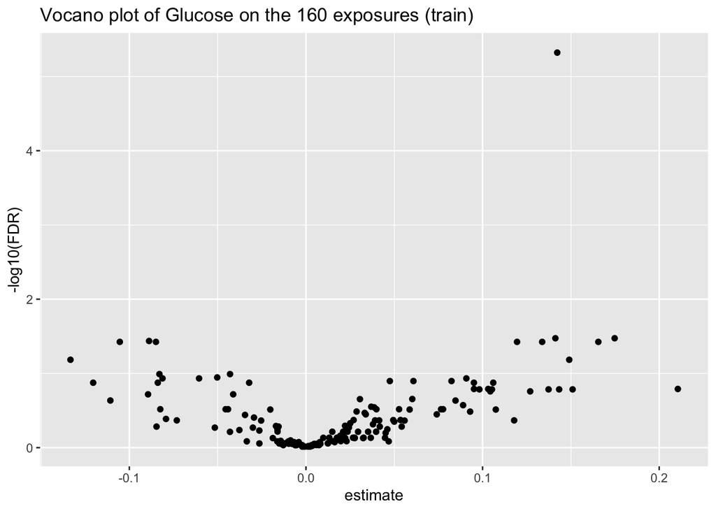

```r
#GLU PLOT
GLU_training_models %>%
  ggplot(aes(x = estimate,y = -log10(FDR)))+
  geom_point()+
  ggtitle("Vocano plot of Glucose on the 160 exposures (train)")
```

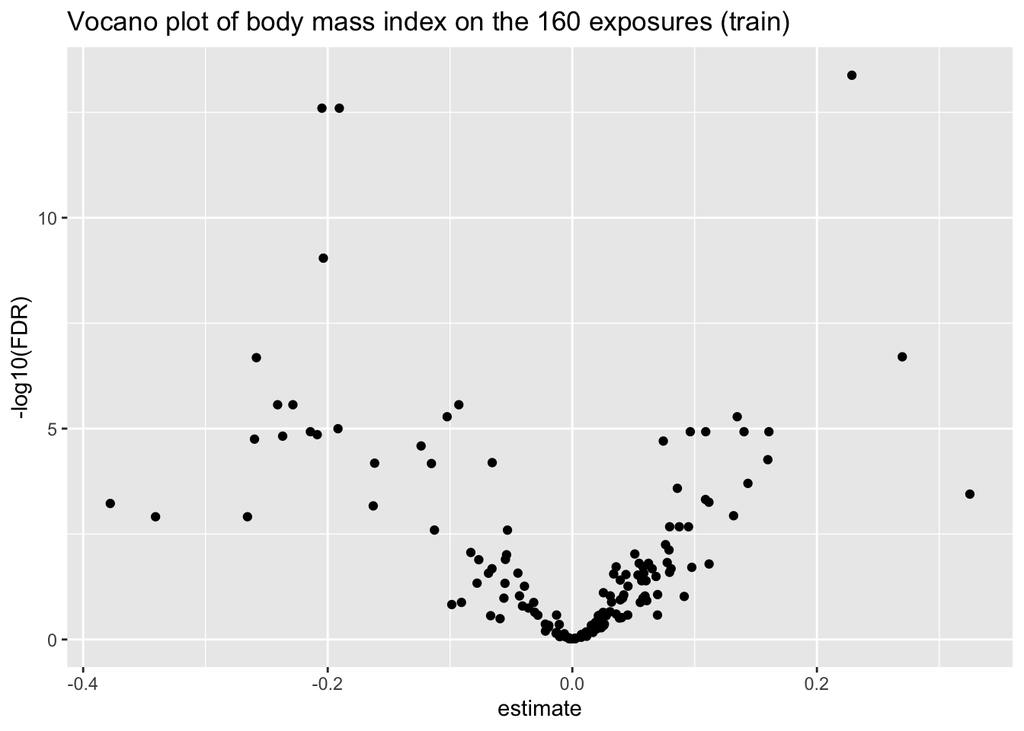

```r
#BMI PLOT
BMI_training_models %>%
  ggplot(aes(x = estimate,y = -log10(FDR)))+
  geom_point()+
  ggtitle("Vocano plot of body mass index on the 160 exposures (train)")
```

4. Filter “replicated” findings using the following heuristic: FDR significance of 0.05 in the training dataset, p-value < 0.05 in the testing dataset, and concordant directionality of associations (e.g., both associations are >0 OR both are <0). Provide your answer in the form of a table with the estimate of the “replicated” findings in the train, test, the FDR from the training data and pvalue from the test cohort data. (3)

```r
GLU_train_clean <- GLU_training_models %>% filter(FDR <= 0.05)
GLU_test_clean <- GLU_testing_models %>% filter(p < 0.05)
GLU_replicated <- inner_join(GLU_train_clean, GLU_test_clean,by = "ExposureList") %>% select(ExposureList, expo_name.x, estimate.x, estimate.y, FDR.x, p.y)

GLU_replicated <- GLU_replicated %>% filter(estimate.x * estimate.y >0)
GLU_replicated
```

```
## # A tibble: 5 x 6
##   ExposureList expo_name.x              estimate.x estimate.y    FDR.x       p.y
##   <chr>        <chr>                         <dbl>      <dbl>    <dbl>     <dbl>
## 1 LBXBHC       Beta-hexachlorocyclohex…     0.166      0.125   3.76e-2   3.03e-2
## 2 LBXBEC       trans-b-carotene(ug/dL)     -0.105     -0.115   3.76e-2   1.42e-6
## 3 LBXCBC       cis-b-carotene(ug/dL)       -0.0888    -0.111   3.66e-2   8.30e-7
## 4 LBXCRY       b-cryptoxanthin(ug/dL)      -0.0849    -0.0575  3.76e-2   5.67e-3
## 5 LBXGTC       g-tocopherol(ug/dL)          0.142      0.125   4.77e-6   2.11e-7
```

```r
BMI_train_clean <- BMI_training_models %>% filter(FDR <= 0.05)
BMI_test_clean <- BMI_testing_models %>% filter(p < 0.05)
BMI_replicated <- inner_join(BMI_train_clean, BMI_test_clean,by = "ExposureList") %>% select(ExposureList, expo_name.x, estimate.x, estimate.y, FDR.x, p.y)

BMI_replicated <- BMI_replicated %>% filter(estimate.x * estimate.y >0)
BMI_replicated
```

```
## # A tibble: 57 x 6
##    ExposureList expo_name.x              estimate.x estimate.y    FDR.x      p.y
##    <chr>        <chr>                         <dbl>      <dbl>    <dbl>    <dbl>
##  1 LBXBPB       Lead (ug/dL)                -0.204     -0.203  9.08e-10 8.82e-12
##  2 LBXCOT       Cotinine (ng/mL)             0.0358     0.0526 1.89e- 2 2.88e- 5
##  3 URXUBA       Barium, urine (ng/mL)        0.0511     0.0774 9.39e- 3 1.31e- 4
##  4 URXUSB       Antimony, urine (ng/mL)      0.0584     0.0482 2.69e- 2 4.27e- 3
##  5 URXUTL       Thallium, urine (ng/mL)      0.0744     0.101  1.97e- 5 3.89e- 5
##  6 LBXB12       Vitamin B12, serum (pg/…    -0.205     -0.190  2.53e-13 1.21e-12
##  7 LBXFOL       Folate, serum (ng/mL)       -0.191     -0.182  2.53e-13 1.77e-14
##  8 LBXVID       Vitamin D (ng/mL)           -0.260     -0.255  1.78e- 5 1.63e-15
##  9 URXMEP       Mono-ethyl phthalate         0.109      0.110  1.18e- 5 1.23e- 5
## 10 URXMZP       Mono-benzyl phthalate        0.0603     0.0579 4.05e- 2 1.58e- 3
## # … with 47 more rows
```

5. Environmental exposures are highly correlated with one another and they can change over time. Therefore, exposures could be subject to many biases. Describe a type of bias (e.g., selection, sampling, or other) that can influence your findings and give an example.(2)
- The survey continued for several years, so the examination tool, lab test method or test accuracy is possible to change over time. For example, sampling Phosphorus data from different parts of the body or the change of the testing machine can cause bias of the data.
6. BMI is a risk factor for diabetes: individuals with higher BMI are at risk for future type 2 diabetes. In this study, we found factors associated with both. For exposures that are found in both BMI and type 2 diabetes - do you think exposure is influencing both traits independently, or via BMI, or neither? Explain why. Optional: Write down a possible linear regression model to test your hypothesis and interpret the finding. (3)
- Some exposures are influencing the diabetes via BMI, but some are not directly causing diabetes via BMI. For instance, exposure A can increase both BMI and glucose(representing another candidate cause of diabetes), but the glucose instead of BMI is the direct cause of diabetes.